# Analyses for SII Experiment 2

### Sample Characteristics

We collected data from a total of N = 170 participants. Following our pre-registered exclusion criteria, we excluded 5 participants whose average correct response times were slower than two standard deviations over the sample mean, 1 who self-reported not having followed the instructions conscientiously, and 1 who rated their own data to be unfit for analysis. This resulted in a sample of N = 163 participants (84 female, 76 male, 3 other, 0 not specified; average age M = 29.9 years, SD = 10.4, ranging from 18 to 69). Participants were recruited via the online platform Prolific (www.prolific.co) and received monetary compensation of 3.13 GBP for completing the 25-minute study. An additional 27 people started the experiment on prolific but either returned their submission, timed-out, or only partially completed the experiment due to technical issues.

On average, participants reported to be rather left leaning (M = 3.9, SD = 1.7 on a scale from 1 = left to 10 = right), rather interested in politics (M = 6.6, SD = 2.2, on a scale ranging from 1 = not at all to 10 = very strongly), and moderately satisfied with the German political system (M = 2.3, SD = 0.5, on a scale ranging from 1 = satisfied to 4 = dissatisfied).

### Preregistered analysis

```r
# Prepare reaction time data
rt <- d_long %>%
  mutate(across(starts_with("rt_"), ~ifelse(is_correct == 0, NA, .))) %>%
  select(subject_id, probe_type, starts_with("rt_")) %>%
  mutate(probe_type = recode(probe_type,
    "im" = "implied", "io" = "implied other")) %>%
  group_by(probe_type, subject_id) %>%
  summarize(.groups = "drop_last", across(everything(), \(x) mean(x, na.rm = TRUE))) %>%
  # Find extreme outliers
  mutate(is_extreme = is_extreme(rt_M2SD_log)) %>%
  ungroup() %T>%
  # Count participants that have extreme outliers
  assign(x = "rt_ex_n", envir = .GlobalEnv, value = n_distinct(
    select(filter(., is_extreme == TRUE), subject_id)))

# Create data frames where these rows are excluded
rt_ex <- filter(rt, is_extreme == FALSE)

# Descriptives
rt_desc <- rt_ex %>%
  group_by(probe_type) %>%
  mutate(rt_M2SD_log_exp = exp(rt_M2SD_log)) %>%
  get_summary_stats(rt_M2SD_log_exp, type = "mean_sd") %>%
  mutate(
    ci95_low = mean - 1.96 * sd / sqrt(n),
    ci95_upp = mean + 1.96 * sd / sqrt(n))

# One-sided paired t-test
rt_t <- rt_ex %>%
  t_test(
    rt_M2SD_log ~ probe_type,
    paired = TRUE,
    alternative = "greater",
    ref.group = "implied")

# Cohens dz
rt_dz <- rt_ex %>%
  cohens_d(rt_M2SD_log ~ probe_type,
    paired = TRUE, ref.group = "implied") %>%
  pull(effsize)

# Print t-test
rt_t_report <- paste0("t(", rt_t$df, ") = ", forma(rt_t$statistic),
  ", ", formp(rt_t$p, TRUE), ", d~z~ = ", forma(rt_dz))
rt_t_plot <- paste0("t(", rt_t$df, ") = ", forma(rt_t$statistic),
  ",\n", formp(rt_t$p, TRUE), ",\nd~z~ = ", forma(rt_dz))
```

To prepare the response latency data for our main anlysis we applied an individual cut-off of the individual mean plus two standard deviations for slow responses and the log-transformation and then computed the average for each experimental condition. For reports of descriptive data we backtransformed the logarithmized values by calculating their exponentials.

#### Outlier detection

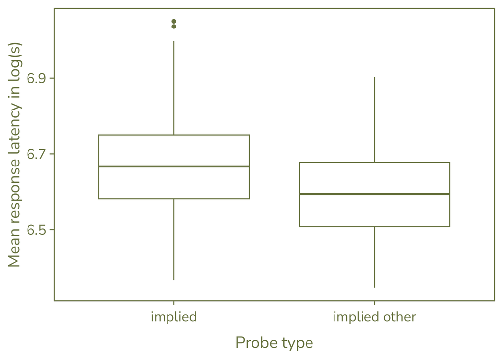

```r
rt_outlier_plot <- rt %>%
  ggplot(., aes(probe_type, rt_M2SD_log)) +
  geom_boxplot(color = "#7A8450") +
  labs(x = "Probe type", y = "Mean response latency in log(s)") +
  theme_cs_talk()
rt_outlier_plot
```

We looked for extreme outliers in each cell of the design. We defined them as values above Q3 + 3 * IQR or below Q1 - 3 * IQR. We found and excluded 0 participants whose values were extreme outliers.

#### QQ-Plot

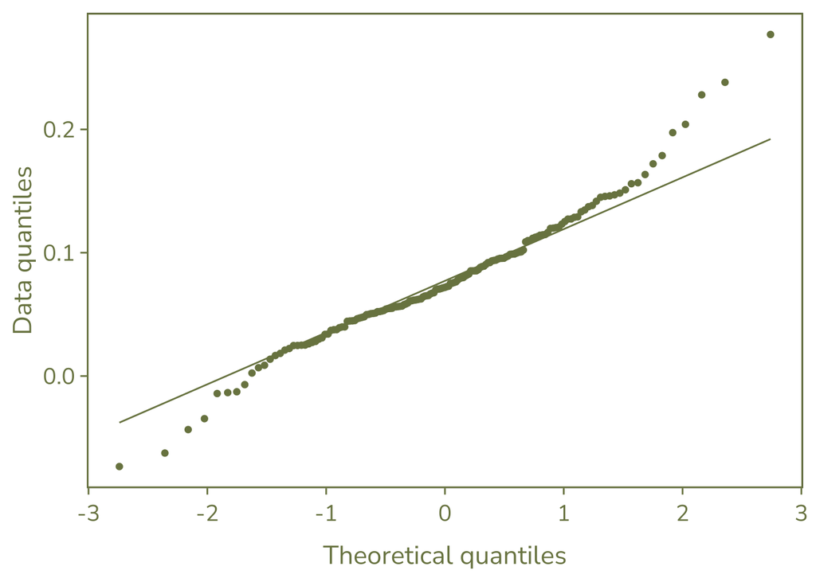

```r
rt_qq_plot <- rt_ex %>%
  pivot_wider(names_from = probe_type, values_from = starts_with("rt_")) %>%
  mutate(diff = rt_M2SD_log_implied - `rt_M2SD_log_implied other`) %>%
  ggplot(., aes(sample = diff)) +
  labs(x = "Theoretical quantiles", y = "Data quantiles") +
  stat_qq(color = "#7A8450") +
  stat_qq_line(color = "#7A8450") +
  theme_cs_talk()
rt_qq_plot
```

Upon visual inspection the differences between the implied and implied-other conditions did not seem severely non-normal. We therefore applied no further transformations before conducting a paired t-test.

#### T-test

On average, participants responded significantly slower in the implied condition (M = 799, SD = 113) than in the implied other condition (M = 738, SD = 93.8), t(162) = 19.0, p < .001, d<sub>z</sub> = 1.49. This indicates that participants spontaneously activated the implied labels while reading the statements.

#### Descriptives

```r
knitr::kable(rt_desc, format = "markdown")
```

| probe_type | variable | n | mean | sd | ci95_low | ci95_upp |
| --- | --- | --- | --- | --- | --- | --- |
| implied | rt_M2SD_log_exp | 163 | 799.074 | 112.775 | 781.7609 | 816.3871 |
| implied other | rt_M2SD_log_exp | 163 | 738.055 | 93.764 | 723.6604 | 752.4496 |

#### Barplot

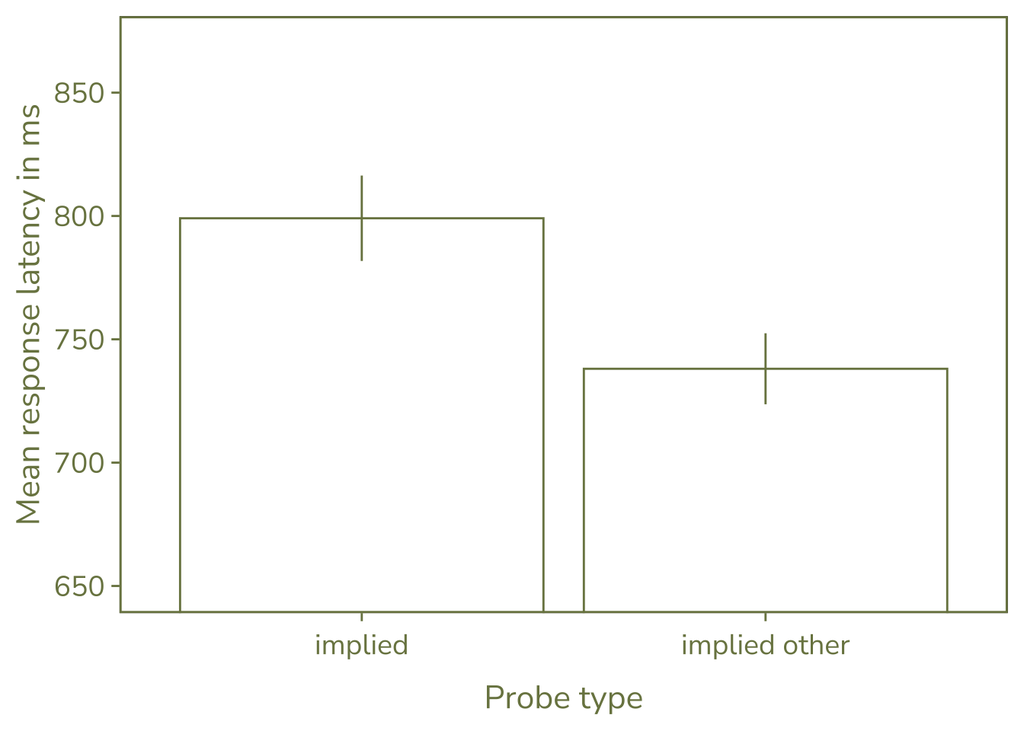

```r
rt_barplot <- rt_desc %>%
  ggplot(., aes(probe_type, mean)) +
  labs(x = "Probe type", y = "Mean response latency in ms") +
  geom_bar(stat = "identity", color = "#7A8450", fill = "white") +
  coord_cartesian(ylim = c(650, 870)) +
  geom_linerange(aes(ymin = ci95_low, ymax = ci95_upp), color = "#7A8450") +
  geom_label(aes(x = 2.08, y = 0.85, label = rt_t_plot),
    fill = "white", color = "#7A8450", show.legend = FALSE,
    label.padding = unit(0.5, "lines"), label.size = 0.5) +
  theme_cs_talk()
rt_barplot
```

#### Multiverse

```r
rt_mv <- d_long %>%
  mutate(across(starts_with("rt_"), ~ifelse(is_correct == 0, NA, .))) %>%
  select(probe_type, subject_id, starts_with("rt_")) %>%
  mutate(probe_type =
    recode(probe_type, "im" = "implied", "io" = "implied other")) %>%
  group_by(probe_type, subject_id) %>%
  summarize(.groups = "drop",
    across(everything(), \(x) mean(x, na.rm = TRUE))) %>%
  pivot_longer(
    cols = starts_with("rt"),
    names_to = c(NA, "cutoff", "trans"),
    values_to = "rt",
    names_sep = "_")

# Loop over all combinations of cutoffs and transformations
mv <- data.frame(
  cutoff = rep(c("none", "M2SD", "f25", "f20", "f15"), 3),
  transformation = c(rep("none", 5), rep("log", 5), rep("inv", 5)))
for (c in seq_along(mv[, 1])) {
  dat <- rt_mv %>%
    # Filter data using c-th cutoff and transformation
    filter(
      cutoff == mv$cutoff[c] &
      trans == mv$transformation[c]) %>%
    group_by(probe_type) %>%
    mutate(is_extreme = is_extreme(rt)) %>%
    ungroup() %T>%
    assign(x = "ex_n", envir = .GlobalEnv, value = n_distinct(
      select(filter(., is_extreme == TRUE), subject_id))) %>%
    filter(is_extreme == FALSE) %>%
    group_by(subject_id) %>%
    filter(n() == 2) %>%
    ungroup()
  test <- dat %>%
    t_test(rt ~ probe_type, paired = TRUE,
      alternative = "greater", ref.group = "implied") %>%
    rowwise() %>%
    mutate(statistic = forma(statistic, 2), p = formp(p))
  dz <- dat %>%
    cohens_d(rt ~ probe_type, paired = TRUE, ref.group = "implied") %>%
    pull(effsize) %>%
    forma()
  # Save test statistics
  mv$ex_n[c] <- ex_n
  mv$t[c] <- test$statistic
  mv$df[c] <- test$df
  mv$p[c] <- test$p
  mv$d_z[c] <- dz
}
# Print multiverse table
knitr::kable(mv, format = "markdown")
```

| cutoff | transformation | ex_n | t | df | p | d_z |
| --- | --- | --- | --- | --- | --- | --- |
| none | none | 1 | 15.44 | 161 | <.001 | 1.21 |
| M2SD | none | 0 | 16.59 | 162 | <.001 | 1.30 |
| f25 | none | 0 | 18.33 | 162 | <.001 | 1.44 |
| f20 | none | 0 | 18.00 | 162 | <.001 | 1.41 |
| f15 | none | 0 | 20.16 | 162 | <.001 | 1.58 |
| none | log | 0 | 20.04 | 162 | <.001 | 1.57 |
| M2SD | log | 0 | 19.03 | 162 | <.001 | 1.49 |
| f25 | log | 0 | 21.49 | 162 | <.001 | 1.68 |
| f20 | log | 0 | 21.06 | 162 | <.001 | 1.65 |
| f15 | log | 0 | 21.92 | 162 | <.001 | 1.72 |
| none | inv | 0 | 21.46 | 162 | <.001 | 1.68 |
| M2SD | inv | 0 | 19.00 | 162 | <.001 | 1.49 |
| f25 | inv | 0 | 21.91 | 162 | <.001 | 1.72 |
| f20 | inv | 0 | 21.50 | 162 | <.001 | 1.68 |
| f15 | inv | 0 | 21.26 | 162 | <.001 | 1.66 |

Because there are no conventions regarding outlier correction and transformations, we follow the example of Krieglmeyer & Deutsch (2010) and employ a multiverse analysis using different cut-off criteria (none, individual M + 2 SD, 2500 ms, 2000 ms, and 1500 ms) and transformations (none, log, inverse) and report each combination’s effects on the results.

The effect of probe type was highly significant across all combinations of cutoff criteria and transformations. The effect size ranged from d<sub>z</sub> = 1.21 for untransformed response latencies with no cutoff to d<sub>z</sub> = 1.72 for log transformed response latencies with a 1500 ms cutoff.

### Exploratory error rate analysis

```r
# Prepare error rate data
er <- d_long %>%
  select(subject_id, probe_type, is_correct) %>%
    mutate(probe_type = recode(probe_type,
      "im" = "implied", "io" = "implied other")) %>%
  group_by(probe_type, subject_id) %>%
  summarize(
    .groups = "drop_last",
    errors = sum(is_correct == 0),
    n_trials = n()) %>%
  mutate(er = errors / n_trials, .keep = "unused") %>%
  ungroup()

# Descriptives
er_desc <- er %>%
  group_by(probe_type) %>%
  get_summary_stats(er, type = "median_iqr")

# One-sided wilcoxon signed-rank test
er_wcx <- er %>%
  wilcox_test(
    er ~ probe_type,
    paired = TRUE,
    alternative = "greater",
    ref.group = "implied")

# Wilcoxon effect size r
er_wcx_r <- er %>%
  wilcox_effsize(er ~ probe_type,
    paired = TRUE, ref.group = "implied") %>%
  pull(effsize)

# Print wilcoxon test
er_wcx_report <- paste0("Z = ", forma(er_wcx_r * sqrt(nrow(er) / 2)),
  ", ", formp(er_wcx$p, TRUE), ", r = ", forma(er_wcx_r))
er_wcx_plot <- paste0("Z = ", forma(er_wcx_r * sqrt(nrow(er) / 2)),
  ",\n", formp(er_wcx$p, TRUE), ",\nr = ", forma(er_wcx_r))
```

We conducted an exploratory error rate analysis to test whether participants not only responded more slowly in the implied condition but also made more errors.

#### QQ-Plot

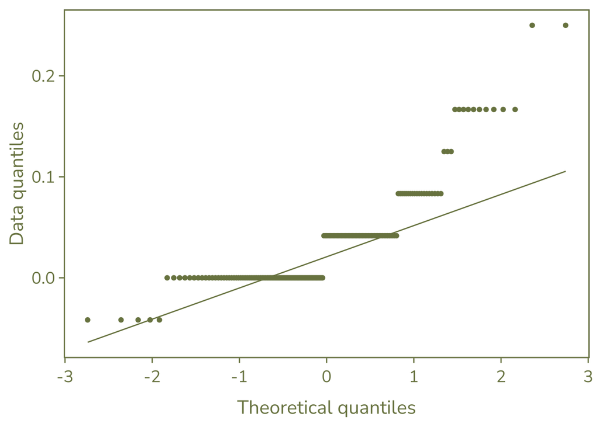

```r
er_normality_plot <- er %>%
  pivot_wider(names_from = probe_type, values_from = er) %>%
  mutate(diff = implied - `implied other`) %>%
  ggplot(., aes(sample = diff)) +
  labs(x = "Theoretical quantiles", y = "Data quantiles") +
  stat_qq(color = "#7A8450") +
  stat_qq_line(color = "#7A8450") +
  theme_cs_talk()
er_normality_plot
```

Upon visual inspection the differences between the implied and implied-other conditions seemed severely non-normal. We therefore conducted a wilcoxon signed-rank test.

#### Skewness

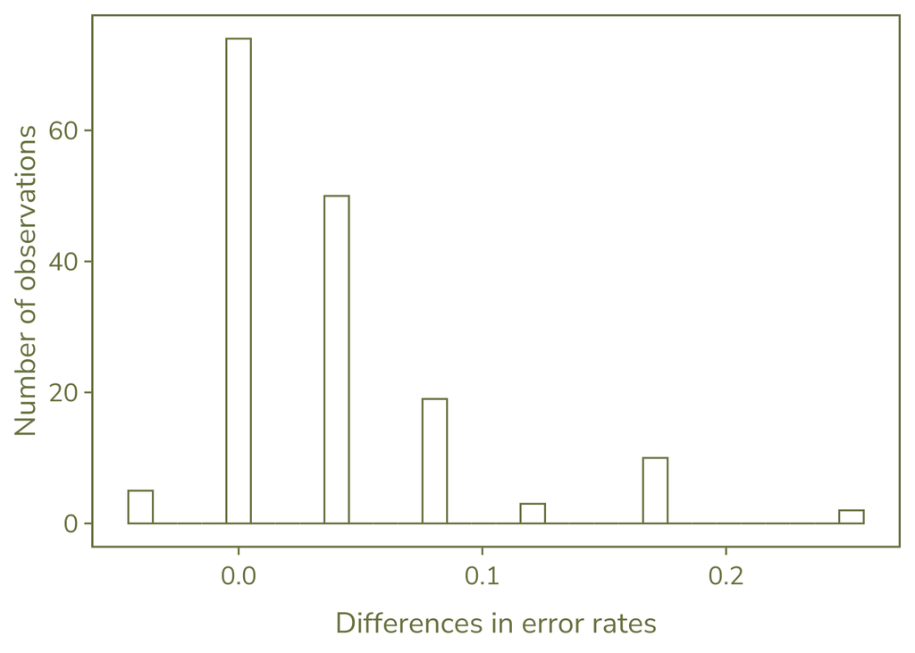

```r
er_skewness_plot <- er %>%
  pivot_wider(names_from = probe_type, values_from = er) %>%
  mutate(diff = implied - `implied other`) %>%
  ggplot(., aes(x = diff)) +
  geom_histogram(color = "#7A8450", fill = "white") +
  labs(x = "Differences in error rates", y = "Number of observations") +
  theme_cs_talk()
er_skewness_plot
```

Upon visual inspection the differences between the implied and implied-other condition seemed severely skewed. Although this violates one of its assumptions, we still computed a wilcoxon signed-rank test.

#### Wilcoxon test

A wilcoxon signed-rank test showed that participants’ error rates were significantly higher in the implied condition (Mdn = 0.042) than in the implied other condition (Mdn = 0), Z = 8.38, p < .001, r = 0.66.

#### Descriptives

```r
knitr::kable(er_desc, format = "markdown")
```

| probe_type | variable | n | median | iqr |
| --- | --- | --- | --- | --- |
| implied | er | 163 | 0.042 | 0.062 |
| implied other | er | 163 | 0.000 | 0.000 |

#### Barplot

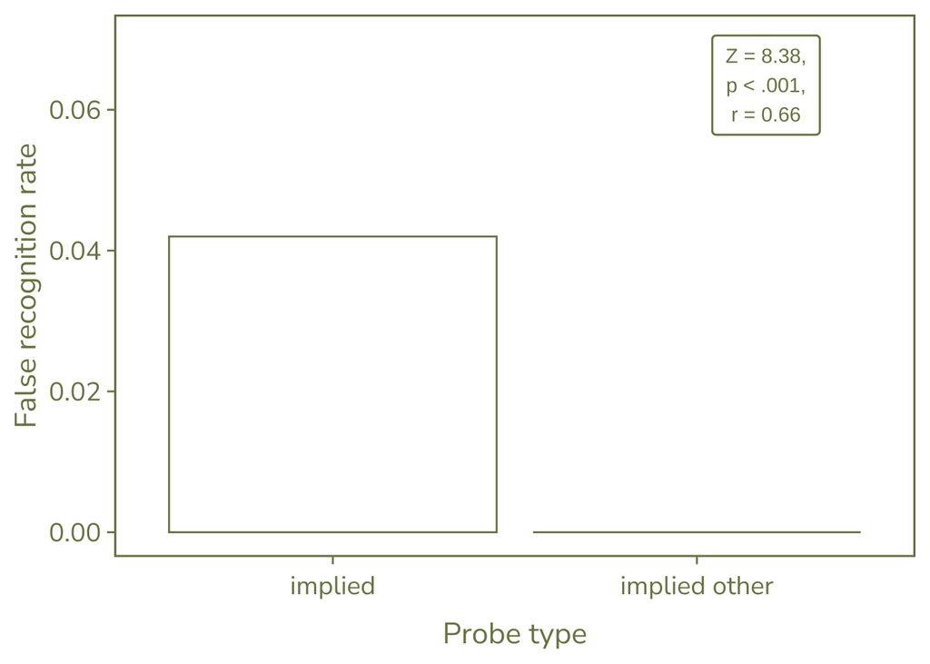

```r
er_barplot <- er_desc %>%
  ggplot(., aes(probe_type, median)) +
  labs(x = "Probe type", y = "False recognition rate") +
  geom_bar(stat = "identity", color = "#7A8450", fill = "white") +
  coord_cartesian(ylim = c(0, 0.07)) +
  geom_label(aes(x = 2.19, y = 0.0635, label = er_wcx_plot),
    fill = "white", color = "#7A8450", show.legend = FALSE,
    label.padding = unit(0.5, "lines"), label.size = 0.5) +
  theme_cs_talk()
er_barplot
```

#### Speed-accuracy trade-off

```r
# Merge response latency and error rate data
d_trade_off <- rt_ex %>%
  left_join(er, by = c("subject_id", "probe_type")) %>%
  select(subject_id, probe_type, rt = rt_M2SD_log, er) %>%
  pivot_wider(names_from = probe_type, values_from = c(er, rt)) %>%
  mutate(
    diff_er = er_implied - `er_implied other`,
    diff_rt = rt_implied - `rt_implied other`, .keep = "unused") %>%
  drop_na()

# Correlation test
trade_off <- cor_test(data = d_trade_off, diff_rt, diff_er)

# Print correlation test
trade_off_report <- paste0("r(", nrow(d_trade_off) - 2, ") = ", forma(trade_off$cor),
  ", ", formp(trade_off$p, TRUE))
```

If there were a trade-off between the speed and accuracy of the participants’ responses, one would expect the SII-effects in the reaction times and error rates to be negatively correlated, such that participants with smaller effects in one outcome show greater effects in the other. A Pearson correlation coefficient was computed to assess the linear relationship between the SII-effects in the reaction times and error rates. There was no significant correlation between the two outcome variables, r(161) = -0.049, p = .538, indicating that participants showing a smaller effect in the reaction times did not show a significantly larger effect in the error rates.

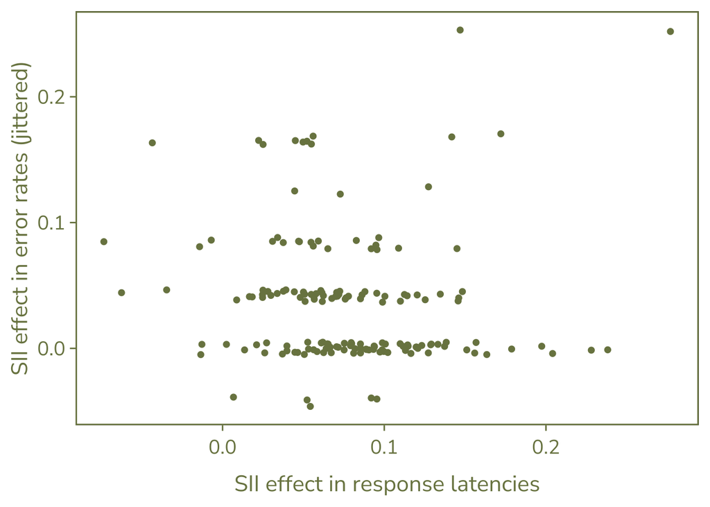

```r
trade_off_plot <- d_trade_off %>%
  ggplot(., aes(x = diff_rt, y = diff_er)) +
  labs(x = "SII effect in response latencies",
      y = "SII effect in error rates (jittered)") +
  geom_jitter(size = 2, shape = 16, height = 0.005, color = "#7A8450") +
  theme_cs_talk()
trade_off_plot
```

### Exploratory by-item and analyses

We conducted exploratory by-item analyses. We grouped the data by label and probe type and aggregated the response latencies (using an individual mean plus two standard deviations cutoff for slow responses and the log-transformation). For each item we calculated the SII-effect as a difference score (implied minus implied-other), with higher values indicating stronger inference effects.

It should be noted, that the difference scores could be calculated in two ways, differing with regards to what is defined as the implied-other label. As we presented two ideological labels after each statement - one implied and one not implied (that is implied in another statement) - the obvious way would be to take the difference between these two labels. However, with the length and currency of the two labels being potentially dissimilar, these differences might be confounded. The less obvious but in our opinion superior way is to take the difference between an implied label and the same label serving as an implied-other label in a different item. This way by-item effects are not confounded by word length or currency.

#### Correlations by label

```r
label_rate <- d_long %>%
  filter(probe_type == "im") %>%
  select(
    label,
    identity = rating_identity,
    valence = rating_valence,
    availability = rating_availability) %>%
  group_by(label) %>%
  summarize(.groups = "drop",
    across(c(identity, valence, availability), \(x) mean(x, na.rm = TRUE)))
label <- d_long %>%
  select(label, behavior, probe_type, rt = rt_M2SD_log, is_correct) %>%
  mutate(across(rt, ~ifelse(is_correct == 0, NA, .)), .keep = "unused") %>%
  group_by(label, behavior, probe_type) %>%
  summarize(.groups = "drop", rt = mean(rt, na.rm = TRUE)) %>%
  pivot_wider(names_from = probe_type, values_from = c(rt, behavior)) %>%
  mutate(sii_effect = rt_im - rt_io, .keep = "unused") %>%
  left_join(label_rate, by = "label")

c1 <- label %>%
  select(sii_effect, identity, valence, availability) %>%
  cor_table()

knitr::kable(c1, format = "markdown")
```

| variable | sii_effect | identity | valence |
| --- | --- | --- | --- |
| identity | -0.30 (.154) |  |  |
| valence | -0.13 (.553) | 0.93 (<.001) |  |
| availability | -0.23 (.286) | 0.39 (.062) | 0.24 (.260) |

The SII-effect was not significantly correlated with any of the ratings. Descriptively the identity ratings most strongly predicted the SII-effect.

#### Identity

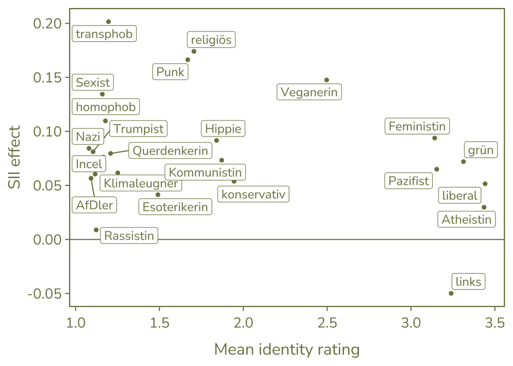

```r
by_item_identity <- label %>%
  ggplot(., aes(x = identity, y = sii_effect)) +
  labs(x = "Mean identity rating", y = "SII effect") +
  geom_abline(intercept = 0, slope = 0, color = "#7A8450") +
  geom_point(color = "#7A8450") +
  geom_label_repel(size = 4.3, label = label$label, box.padding = 0.2,
    family = "Nunito", color = "#7A8450") +
  theme_cs_talk()
by_item_identity
```

#### Valence

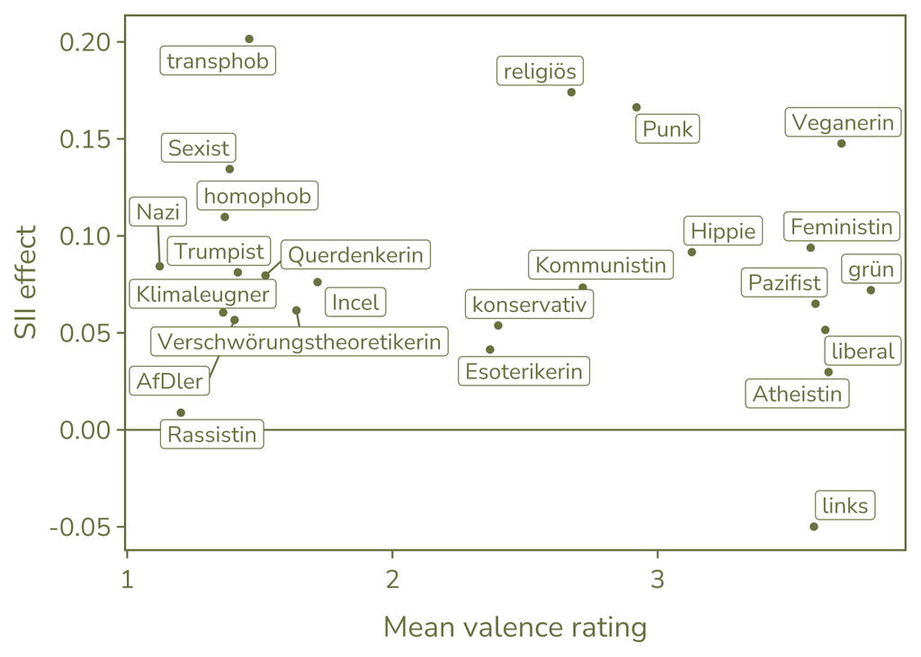

```r
by_item_valence <- label %>%
  ggplot(., aes(x = valence, y = sii_effect)) +
  labs(x = "Mean valence rating", y = "SII effect") +
  geom_abline(intercept = 0, slope = 0, color = "#7A8450") +
  geom_point(color = "#7A8450") +
  geom_label_repel(size = 4.3, label = label$label, box.padding = 0.2,
    family = "Nunito", color = "#7A8450") +
  theme_cs_talk()
by_item_valence
```

#### Availability

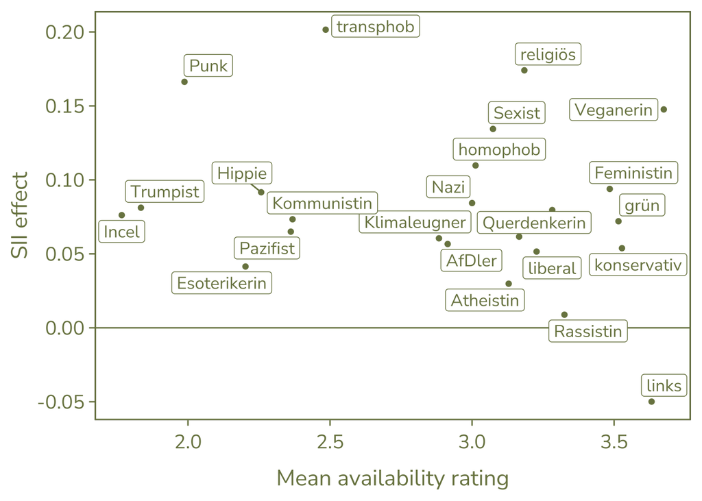

```r
by_item_availability <- label %>%
  ggplot(., aes(x = availability, y = sii_effect)) +
  labs(x = "Mean availability rating", y = "SII effect") +
  geom_abline(intercept = 0, slope = 0, color = "#7A8450") +
  geom_point(color = "#7A8450") +
  geom_label_repel(size = 4.3, label = label$label, box.padding = 0.2,
    family = "Nunito", color = "#7A8450") +
  theme_cs_talk()
by_item_availability
```

### Exploratory multilevel analyses

```r
d_mlm_label <- d_long %>%
  # Set RTs of incorrect responses to NA
  mutate(rt = ifelse(is_correct == 0, NA, rt_M2SD_none), .keep = "unused") %>%
  select(
    subject_id, item_id, label, probe_type, rt, starts_with("rating_"),
    age, gender, starts_with("pol_")) %>%
  pivot_wider(
    names_from = probe_type,
    values_from = c(matches("rt|rating|item_id")),
    names_sep = "_") %>%
  mutate(
    sii_effect = rt_im - rt_io,
    gender = na_if(gender, "other"),
    # Grand mean center level 2 predictors
    age = age - mean(age, na.rm = TRUE),
    pol_orientation = pol_orientation - mean(pol_orientation),
    pol_interest = pol_interest - mean(pol_interest),
    pol_satisfaction = pol_satisfaction - mean(pol_satisfaction)
  ) %>%
  group_by(subject_id) %>%
  mutate(
    # Group mean center level 1 predictors
    availability = rating_availability_im - mean(rating_availability_im),
    valence = rating_valence_im - mean(rating_valence_im),
    identity = rating_identity_im - mean(rating_identity_im)
  ) %>%
  ungroup() %>%
  left_join(
    select(label, -behavior_im, -behavior_io, -sii_effect),
    by = "label", suffix = c("", "_label")) %>%
  mutate(
    # Grand mean center level 2 predictors
    identity_label = identity_label - mean(identity_label),
    valence_label = valence_label - mean(valence_label),
    availability_label = availability_label - mean(availability_label)) %>%
  select(-matches("rating_|rt_"))

c2 <- d_mlm_label %>%
  select(sii_effect, identity, valence, availability) %>%
  cor_table()
```

#### Zero-order by label

```r
knitr::kable(c2, format = "markdown")
```

| variable | sii_effect | identity | valence |
| --- | --- | --- | --- |
| identity | -0.07 (<.001) |  |  |
| valence | -0.04 (.044) | 0.79 (<.001) |  |
| availability | 0.00 (.928) | 0.24 (<.001) | 0.11 (<.001) |

```r
mlm1 <- lmer(sii_effect ~ identity +
        (1 | subject_id) + (1 | label),
        data = d_mlm_label, REML = FALSE)
mlm2 <- lmer(sii_effect ~ valence +
        (1 | subject_id) + (1 | label),
        data = d_mlm_label, REML = FALSE)
mlm3 <- lmer(sii_effect ~ availability +
        (1 | subject_id) + (1 | label),
        data = d_mlm_label, REML = FALSE)
```

#### Model I

```r
sjPlot::tab_model(mlm1)
```

|  | sii_effect |  |  |
| --- | --- | --- | --- |
| Predictors | Estimates | CI | p |
| (Intercept) | 67.09 | 49.45 – 84.74 | **<0.001** |
| identity | -6.53 | -13.08 – 0.01 | 0.050 |
| Random Effects |  |  |  |
| σ<sup>2</sup> | 28952.12 |  |  |
| τ<sub>00</sub> <sub>subject_id</sub> | 784.49 |  |  |
| τ<sub>00</sub> <sub>label</sub> | 1618.83 |  |  |
| ICC | 0.08 |  |  |
| N <sub>subject_id</sub> | 163 |  |  |
| N <sub>label</sub> | 24 |  |  |
| Observations | 3367 |  |  |
| Marginal R<sup>2</sup> / Conditional R<sup>2</sup> | 0.002 / 0.078 |  |  |

#### Model II

```r
sjPlot::tab_model(mlm2)
```

|  | sii_effect |  |  |
| --- | --- | --- | --- |
| Predictors | Estimates | CI | p |
| (Intercept) | 67.15 | 49.12 – 85.17 | **<0.001** |
| valence | -4.68 | -11.69 – 2.33 | 0.191 |
| Random Effects |  |  |  |
| σ<sup>2</sup> | 28963.10 |  |  |
| τ<sub>00</sub> <sub>subject_id</sub> | 781.01 |  |  |
| τ<sub>00</sub> <sub>label</sub> | 1704.05 |  |  |
| ICC | 0.08 |  |  |
| N <sub>subject_id</sub> | 163 |  |  |
| N <sub>label</sub> | 24 |  |  |
| Observations | 3367 |  |  |
| Marginal R<sup>2</sup> / Conditional R<sup>2</sup> | 0.001 / 0.080 |  |  |

#### Model III

```r
sjPlot::tab_model(mlm3)
```

|  | sii_effect |  |  |
| --- | --- | --- | --- |
| Predictors | Estimates | CI | p |
| (Intercept) | 67.24 | 48.81 – 85.67 | **<0.001** |
| availability | 5.27 | -1.21 – 11.75 | 0.111 |
| Random Effects |  |  |  |
| σ<sup>2</sup> | 28943.75 |  |  |
| τ<sub>00</sub> <sub>subject_id</sub> | 784.47 |  |  |
| τ<sub>00</sub> <sub>label</sub> | 1795.77 |  |  |
| ICC | 0.08 |  |  |
| N <sub>subject_id</sub> | 163 |  |  |
| N <sub>label</sub> | 24 |  |  |
| Observations | 3367 |  |  |
| Marginal R<sup>2</sup> / Conditional R<sup>2</sup> | 0.001 / 0.083 |  |  |

```r
ggexport(rt_outlier_plot, width = 5, height = 5,
  filename = here("Analysis/rt-outlier-plot.pdf"))
ggexport(rt_qq_plot, width = 5, height = 5,
      filename = here("Analysis/rt-qq-plot.pdf"))
ggexport(rt_barplot, width = 4, height = 5,
      filename = here::here("Analysis/rt-barplot.pdf"))
ggexport(er_normality_plot, width = 5, height = 5,
      filename = here::here("Analysis/er-normality-plot.pdf"))
ggexport(er_skewness_plot, width = 5, height = 5,
      filename = here::here("Analysis/er-skewness-plot.pdf"))
ggexport(er_barplot, width = 4, height = 5,
      filename = here::here("Analysis/er-barplot.pdf"))
ggexport(trade_off_plot, width = 7, height = 6,
      filename = here::here("Analysis/trade-off-plot.pdf"))
ggexport(by_item_identity, width = 7, height = 6,
      filename = here::here("Analysis/by-item-identity.pdf"))
ggexport(by_item_availability, width = 7, height = 6,
      filename = here::here("Analysis/by-item-availability.pdf"))
ggexport(by_item_valence, width = 7, height = 6,
      filename = here::here("Analysis/by-item-valence.pdf"))
```